# Udacity - Machine Learning Engineer Nanodegree Program

## Final Capstone Project

### Stock Price Prediction Using Machine Learning

In this project, I will use the power of Machine Learning to predict the Stock closing price using some of models namely LSTM and GRU to predict the Amazon's (FAANG stock) closing price.

### Common Modules for the project

```python
import quandl
import numpy as np
import pandas as pd
import math

import seaborn as sns
import matplotlib.pyplot as plt

from sklearn.preprocessing import MinMaxScaler
from keras.layers import BatchNormalization

from sklearn.model_selection import train_test_split

import keras
from keras.models import Sequential
from keras.layers.core import Dense, Dropout, Activation
from keras.layers.recurrent import LSTM,GRU
from sklearn import linear_model

from sklearn.metrics import mean_squared_error
from math import sqrt
```

### Stock data downloader

Pull the data from Quandl first and add the 50days, 100days, 200days into [50, 100, 200] In the Quandl database, Open, High, Low, Close, Volume are all adjusted.

```python
## Stock downloader..
def download_stock_data(stock):
    columns = ['date','adj_open','adj_low','adj_high','adj_volume','adj_close']
    quandl.ApiConfig.api_key = 'RcePNacJwS3WiJR-kww_'

    data = quandl.get_table('WIKI/PRICES', ticker = stock, qopts = { 'columns': columns })
     # Renaming all the columns so that we can use the old version code
    data.rename(columns={'adj_open': 'Open', 'adj_high': 'High', 'adj_low': 'Low', 'adj_volume': 'Volume'}, inplace=True)
    data.set_index('date', inplace=True)
    return data
```

```python
df = download_stock_data('AMZN')
df.to_csv('amazon.csv',index = False)
df.head()
```

| date | Open | Low | High | Volume | adj_close |
| --- | --- | --- | --- | --- | --- |
| 1997-05-16 | 1.865000 | 1.708333 | 1.979167 | 14700000.0 | 1.729167 |
| 1997-05-19 | 1.708333 | 1.625000 | 1.770833 | 6106800.0 | 1.708333 |
| 1997-05-20 | 1.729167 | 1.635833 | 1.750000 | 5467200.0 | 1.635833 |
| 1997-05-21 | 1.604167 | 1.375000 | 1.645833 | 18853200.0 | 1.427500 |
| 1997-05-22 | 1.437500 | 1.312500 | 1.448333 | 11776800.0 | 1.395833 |

### Normalize the Stock data and add more technical features

Now, Add more add the PCT 50days, 100days, 200days into [50, 100, 200]

```python
## Define a normalizer for stock data
def process_and_normalize(df,ma=[50,100,200]):
    # Percentage change
    df['Pct'] = df['adj_close'].pct_change()
    df.dropna(inplace=True)

    # Moving Average
    if ma != []:
        for moving in ma:
            df['{}ma'.format(moving)] = df['adj_close'].rolling(window=moving).mean()
    df.dropna(inplace=True)

     # Initialize a scaler, then apply it to the features
    scaler = MinMaxScaler()
    numerical = ['Open', 'Low','High' ,'Volume','adj_close','Pct','50ma','100ma','200ma']
    df[numerical] = scaler.fit_transform(df[numerical])
    # Move Adj Close to the rightmost for the ease of training
    adj_close = df['adj_close']
    df.drop(labels=['adj_close'], axis=1, inplace=True)
    df = pd.concat([df, adj_close], axis=1)

    return df
```

```python
df = process_and_normalize(df)
df.head()
```

| date | Open | Low | High | Volume | Pct | 50ma | 100ma | 200ma | adj_close |
| --- | --- | --- | --- | --- | --- | --- | --- | --- | --- |
| 1998-03-04 | 0.000056 | 0.000204 | 0.000054 | 0.061247 | 0.457843 | 0.000000 | 0.000000 | 0.000000 | 0.000094 |
| 1998-03-05 | 0.000043 | 0.000270 | 0.000258 | 0.106602 | 0.453940 | 0.000024 | 0.000019 | 0.000020 | 0.000176 |
| 1998-03-06 | 0.000244 | 0.000401 | 0.000197 | 0.047441 | 0.457471 | 0.000047 | 0.000038 | 0.000041 | 0.000267 |
| 1998-03-09 | 0.000308 | 0.000559 | 0.000649 | 0.213569 | 0.566548 | 0.000079 | 0.000061 | 0.000065 | 0.000621 |
| 1998-03-10 | 0.000755 | 0.000881 | 0.000778 | 0.229964 | 0.410197 | 0.000111 | 0.000083 | 0.000089 | 0.000600 |

```python
plt.rcParams['figure.figsize'] = (18, 12)
## Visualize the stock data.
def plot_stock_data(df):
    plt.subplot(211)
    plt.plot(df['adj_close'], color='red', label='Adj Close')
    plt.legend(loc='best')
    plt.subplot(212)
    plt.plot(df['Pct'], color='blue', label='Percentage change')
    plt.legend(loc='best')
    plt.show()

## visualize the data correlation
def plot_stock_corr(df):
    corr = df.corr()
    ax = sns.heatmap(corr, cmap="YlGnBu")
    plt.show()
```

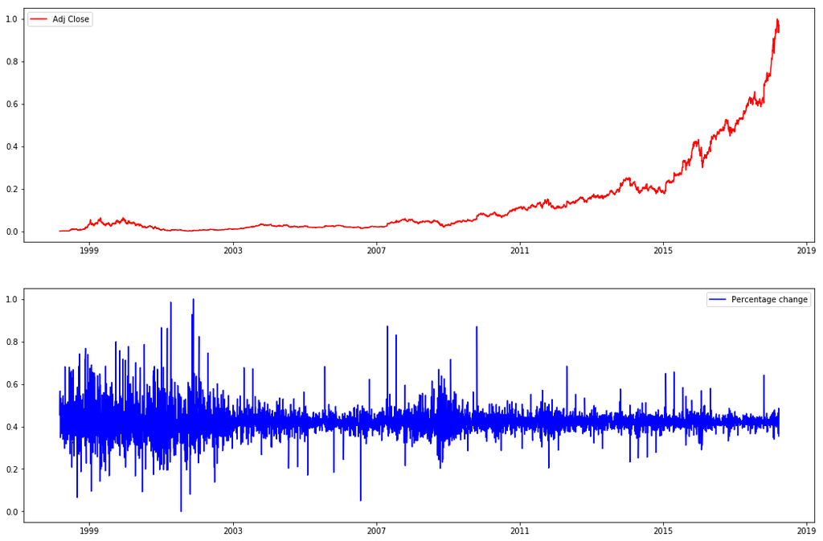

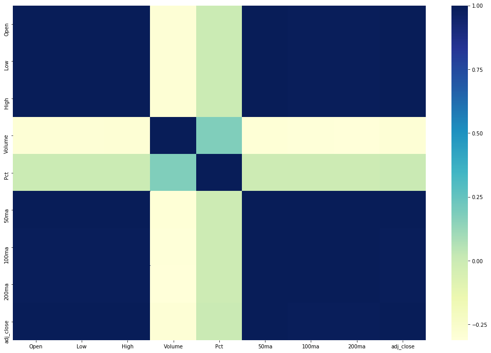

```python
plot_stock_data(df)
plot_stock_corr(df)
```

```python
## Define a function to eval the mean for few columns.
def show_min_max(data):
    print(data.head())

    print("\n")
    print("Open   - mean :", np.mean(data['Open']),  " Std: ", np.std(data['Open']),  " Max: ", np.max(data['Open']),  " Min: ", np.min(data['Open']))
    print("Low    - mean :", np.mean(data['Low']), " Std: ", np.std(data['Low']), " Max: ", np.max(data['Low']), " Min: ", np.min(data['Low']))
    print("High   - mean :", np.mean(data['High'])," Std: ", np.std(data['High'])," Max: ", np.max(data['High'])," Min: ", np.min(data['High']))
    print("Close  - mean :", np.mean(data['adj_close']), "   Std: ", np.std(data['adj_close']), " Max: ", np.max(data['adj_close']), " Min: ", np.min(data['adj_close']))
    print("Volume - mean :", np.mean(data['Volume'])," Std: ", np.std(data['Volume'])," Max: ", np.max(data['Volume'])," Min: ", np.min(data['Volume']))
```

```python
show_min_max(df)
```

```
                Open       Low      High    Volume       Pct      50ma  \
date
1998-03-04  0.000056  0.000204  0.000054  0.061247  0.457843  0.000000
1998-03-05  0.000043  0.000270  0.000258  0.106602  0.453940  0.000024
1998-03-06  0.000244  0.000401  0.000197  0.047441  0.457471  0.000047
1998-03-09  0.000308  0.000559  0.000649  0.213569  0.566548  0.000079
1998-03-10  0.000755  0.000881  0.000778  0.229964  0.410197  0.000111

               100ma     200ma  adj_close
date
1998-03-04  0.000000  0.000000   0.000094
1998-03-05  0.000019  0.000020   0.000176
1998-03-06  0.000038  0.000041   0.000267
1998-03-09  0.000061  0.000065   0.000621
1998-03-10  0.000083  0.000089   0.000600


('Open   - mean :', 0.12634242367338944, ' Std: ', 0.1767287238240672, ' Max: ', 1.0, ' Min: ', 0.0)
('Low    - mean :', 0.1269081379555572, ' Std: ', 0.17777602995612357, ' Max: ', 0.99999999999999989, ' Min: ', 0.0)
('High   - mean :', 0.12761806629793893, ' Std: ', 0.17793269415850474, ' Max: ', 1.0, ' Min: ', 0.0)
('Close  - mean :', 0.12771623149191222, '   Std: ', 0.1786324688100984, ' Max: ', 1.0000000000000002, ' Min: ', 0.0)
('Volume - mean :', 0.06726450448090572, ' Std: ', 0.07328023454728129, ' Max: ', 0.99999999999999989, ' Min: ', 0.0)
```

```python
## Save to CSV for future use
df.to_csv('amazon_normalized.csv',index = False)
```

## Section - 1 : Data processing, Design Bench Mark Model, Training, Prediction & Accuracy

### Step : 1

**Data Processing, choosing less set of feartures**

```python
## Define a function to process the data
def process_stock_data(data):
    # Define fewer columns of features
    item = []
    open = []
    close = []
    volume = []

    # Loop through the data
    i_counter = 0
    for i in range(len(data) - 1):
        item.append(i_counter)
        open.append(data['Open'][i])
        close.append(data['adj_close'][i])
        volume.append(data['Volume'][i])
        i_counter += 1

    stocks = pd.DataFrame()

    # Add factors to data frame
    stocks['Item'] = item
    stocks['Open'] = open
    stocks['Close'] = pd.to_numeric(close)
    stocks['Volume'] = pd.to_numeric(volume)

    return stocks
```

```python
regression_df = process_stock_data(df)
regression_df.head()
```

|  | Item | Open | Close | Volume |
| --- | --- | --- | --- | --- |
| 0 | 0 | 0.000056 | 0.000094 | 0.061247 |
| 1 | 1 | 0.000043 | 0.000176 | 0.106602 |
| 2 | 2 | 0.000244 | 0.000267 | 0.047441 |
| 3 | 3 | 0.000308 | 0.000621 | 0.213569 |
| 4 | 4 | 0.000755 | 0.000600 | 0.229964 |

```python
## Define visualize function
def price(x):
    return '$%1.2f' % x

def plot_regression_data(stocks, title='Amazon Trading', y_label='Price', x_label='Trading Days'):
    fig, ax = plt.subplots()
    ax.plot(stocks['Item'], stocks['Close'], 'red')

    ax.format_ydata = price
    ax.set_title(title)

    # Add labels
    plt.ylabel(y_label)
    plt.xlabel(x_label)

    plt.show()
```

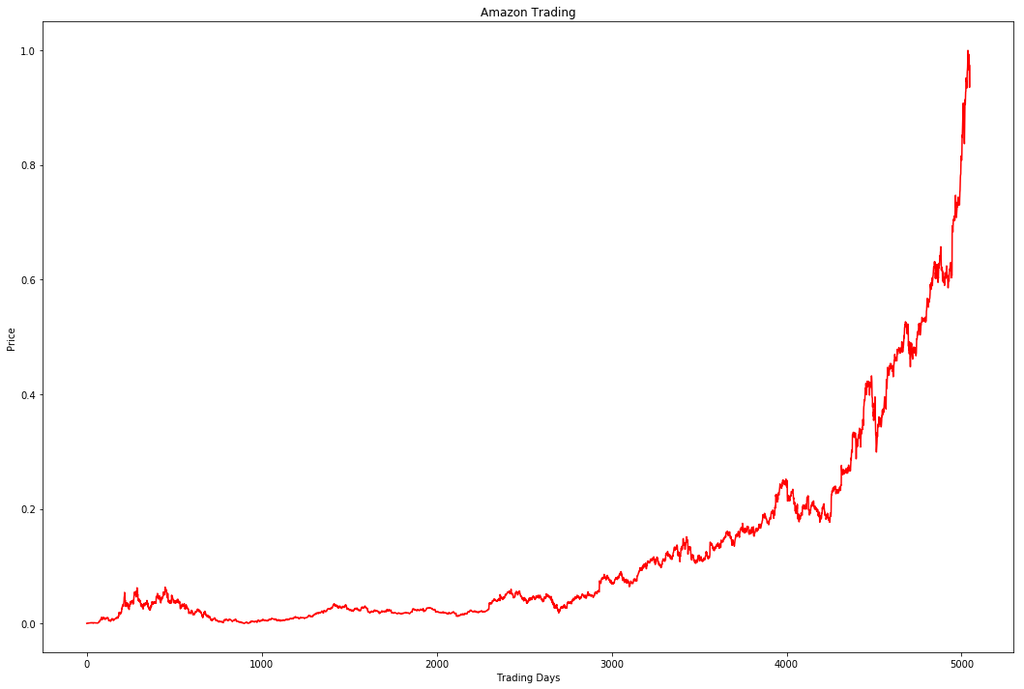

```python
plot_regression_data(regression_df)
```

### Step : 2

**Split the data**

```python
## Define the method to split the data into Test and Train for model.
def split_train_test_linear_regression_basic(df):
    adj_close = df['Close'].tolist()
    date      = df['Item'].tolist()

    #Convert to 1d Vector
    date = np.reshape(date, (len(date), 1))
    adj_close = np.reshape(adj_close, (len(adj_close), 1))
    X_train, X_test, y_train, y_test = train_test_split(date, adj_close, test_size=0.30, random_state=42)
    return X_train, X_test, y_train, y_test
```

```python
# X_train, X_test, y_train, y_test, label_range= split_train_test_linear_regression(regression_df)
X_train, X_test, y_train, y_test = split_train_test_linear_regression_basic(regression_df)

print("x_train", X_train.shape)
print("y_train", y_train.shape)
print("x_test", X_test.shape)
print("y_test", y_test.shape)
```

```
('x_train', (3532, 1))
('y_train', (3532, 1))
('x_test', (1515, 1))
('y_test', (1515, 1))
```

### Step : 3

**Design the Benchmark Regression Model**

```python
## Define a function for Linear Regression.
def build_linear_regression_model_basic(X, y):
    linear_mdl = linear_model.LinearRegression()
    linear_mdl.fit(X, y)

    return linear_mdl
```

### Step : 4

**Compile the model and fit the data**

```python
regression_model = build_linear_regression_model_basic(X_train,y_train)
```

### Step : 5

**Use the model for data prediction**

```python
predictions = regression_model.predict(X_test)
```

### Step : 6

**Use prediction data to visualize**

```python
def plot_func(regressor,X_test,y_test ):
    plt.scatter(X_test, y_test, color='red', label= 'Actual Price') #plotting the initial datapoints
    plt.plot(X_test, regressor.predict(X_test), color='blue', linewidth=3, label = 'Predicted Price') #plotting the line made by linear regression
    plt.title('Linear Regression | Time vs. Price')
    plt.legend()
    plt.xlabel('Date Integer')
    plt.show()
```

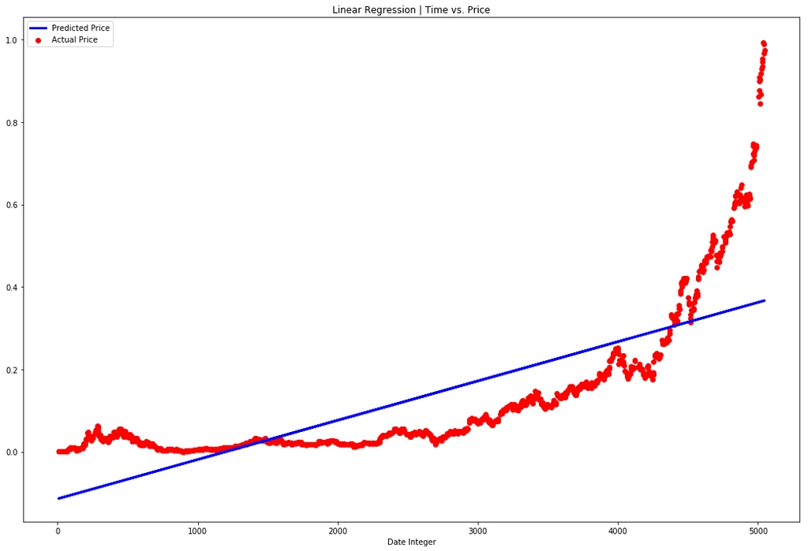

```python
plot_func(regression_model,X_test,y_test)
```

### Step : 7

**Calculate the model error**

```python
def calculate_model_error_accuracy(X_train, y_train, y_test,predictions):
    trainScore = mean_squared_error(X_train, y_train)
    print('Train Score: %.4f MSE (%.4f RMSE)' % (trainScore, math.sqrt(trainScore)))

    testScore = mean_squared_error(predictions, y_test)
    print('Test Score: %.8f MSE (%.8f RMSE)' % (testScore, math.sqrt(testScore)))
```

```python
## Calculate the errors
calculate_model_error_accuracy(X_train, y_train, y_test,predictions)
```

```
Train Score: 8534412.4325 MSE (2921.3717 RMSE)
Test Score: 0.01290567 MSE (0.11360313 RMSE)
```

## Section - 2 : Data Split, Design LSTM Model, Training, Prediction & Accuracy

### Step : 1

**Define the split function for LSTM model**

```python
## Define the Data split function based on a sequence length.

def split_train_test_lstm(stock, seq_len):
    amount_of_features = len(stock.columns)
    print ("Amount of features = {}".format(amount_of_features))
    data = stock.as_matrix()
    sequence_length = seq_len + 1 # index starting from 0
    result = []

    for index in range(len(data) - sequence_length): # maxmimum date = lastest date - sequence length
        result.append(data[index: index + sequence_length]) # index : index + 22days

    result = np.array(result)
    row = round(0.8 * result.shape[0]) # 80% split
    print ("Amount of training data = {}".format(0.9 * result.shape[0]))
    print ("Amount of testing data = {}".format(0.1 * result.shape[0]))

    train = result[:int(row), :] # 90% date
    X_train = train[:, :-1] # all data until day m
    y_train = train[:, -1][:,-1] # day m + 1 adjusted close price

    X_test = result[int(row):, :-1]
    y_test = result[int(row):, -1][:,-1]

    X_train = np.reshape(X_train, (X_train.shape[0], X_train.shape[1], amount_of_features))
    X_test = np.reshape(X_test, (X_test.shape[0], X_test.shape[1], amount_of_features))

    return [X_train, y_train, X_test, y_test]
```

```python
seq_len = 22
shape = [seq_len, 9, 1]
neurons = [256, 32, 1]
lstm_df = df
X_train, y_train, X_test, y_test = split_train_test_lstm(lstm_df, seq_len)
```

```
Amount of features = 9
Amount of training data = 4522.5
Amount of testing data = 502.5
```

### Step : 2

**Design a basic LSTM model**

```python
def build_basic_model(shape, neurons):
    model = Sequential()

    model.add(LSTM(neurons[0], input_shape=(shape[0], shape[1]), return_sequences=True))
    model.add(LSTM(neurons[1], input_shape=(shape[0], shape[1]), return_sequences=False))

    model.add(Dense(neurons[2],activation='linear'))

    model.compile(loss='mse',optimizer='adam', metrics=['accuracy'])

    model.summary()

    return model
```

### Step : 3

**Build and compile basic LSTM model**

```python
lstm_basic_model = build_basic_model(shape,neurons)
```

[output not shown]

### Step : 4

**Train basic LSTM model**

```python
epochs = 1
lstm_basic_model.fit(X_train, y_train,epochs=epochs,validation_split=0.2)
```

```
Train on 3216 samples, validate on 804 samples
```

```
<keras.callbacks.History at 0x1aede2ef90>
```

### Step : 5

**Prediction using basic LSTM model**

```python
predictions = lstm_basic_model.predict(X_test)
```

```python
## Define a visualize function to plot the lstm prediction..
def plot_lstm_stock_prediction(actual, prediction, title='Amazon Prediction', y_label='Price', x_label='Trading Days'):

    fig = plt.figure()
    ax = fig.add_subplot(111)

    # Add labels
    plt.ylabel(y_label)
    plt.xlabel(x_label)

    # Plot actual and predicted close values

    plt.plot(actual, 'red', label='Adjusted Close')
    plt.plot(prediction, 'blue', label='Predicted Close')

    # Set title
    ax.set_title(title)
    ax.legend(loc='upper left')

    plt.show()
```

### Step : 6

**Plot the predictions using basic LSTM model**

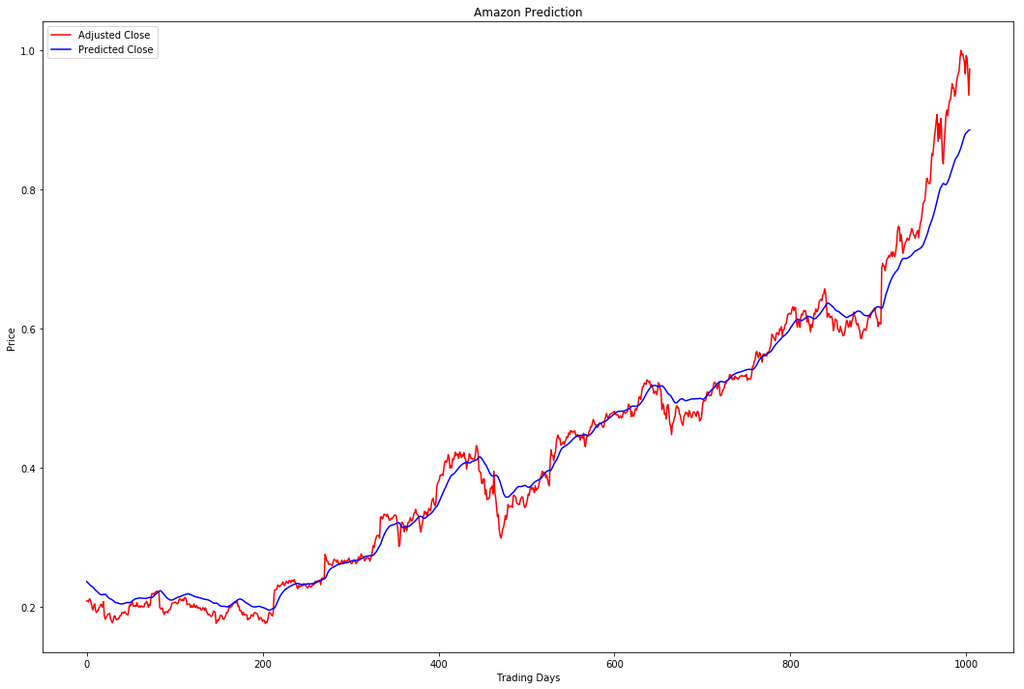

```python
plot_lstm_stock_prediction(y_test,predictions)
```

### Step : 7

**Error/accuracy score of basic LSTM model**

```python
## Define a function to eval the errors.
def model_lstm_score(model, X_train, y_train, X_test, y_test):
    trainScore = model.evaluate(X_train, y_train, verbose=0)
    print('Train Score: %.8f MSE (%.8f RMSE)' % (trainScore[0], math.sqrt(trainScore[0])))

    testScore = model.evaluate(X_test, y_test, verbose=0)
    print('Test Score: %.8f MSE (%.8f RMSE)' % (testScore[0], math.sqrt(testScore[0])))
    return trainScore[0], testScore[0]
```

```python
model_lstm_score(lstm_basic_model,X_train, y_train, X_test, y_test)
```

[output not shown]

[output not shown]

### Optimised LSTM Model

**Step : 1 - Build the enhanced Model**

```python
def build_optimized_lstm_model(shape, neurons, dropout):
    model = Sequential()

    model.add(LSTM(neurons[0], input_shape=(shape[0], shape[1]), return_sequences=True))
    model.add(Dropout(dropout))

    model.add(LSTM(neurons[1], input_shape=(shape[0], shape[1]), return_sequences=False))

    model.add(Dropout(dropout))

    model.add(Dense(neurons[2],activation='linear'))

    model.compile(loss='mse',optimizer='adam', metrics=['accuracy'])
    model.summary()
    return model
```

#### Step : 2 - Compile the model with optimized params

```python
seq_len = 22
shape = [seq_len, 9, 1]
neurons = [256, 128, 1]
dropout = 0.2
epochs = 20
batch_size = 100
validation_split = 0.2
optimized_lstm_model = build_optimized_lstm_model(shape, neurons, dropout)
```

```
_________________________________________________________________
Layer (type)                 Output Shape              Param #
=================================================================
lstm_17 (LSTM)               (None, 22, 256)           272384
_________________________________________________________________
dropout_22 (Dropout)         (None, 22, 256)           0
_________________________________________________________________
lstm_18 (LSTM)               (None, 128)               197120
_________________________________________________________________
dropout_23 (Dropout)         (None, 128)               0
_________________________________________________________________
dense_18 (Dense)             (None, 1)                 129
=================================================================
Total params: 469,633
Trainable params: 469,633
Non-trainable params: 0
_________________________________________________________________
```

### Step : 3

**Train using Optimized LSTM model**

```python
optimized_lstm_model.fit(
                        X_train,
                        y_train,
                        batch_size=batch_size,
                        epochs=epochs,
                        validation_split=validation_split,
                        verbose=1)
```

```
Train on 3216 samples, validate on 804 samples
```

```
<keras.callbacks.History at 0x1aff3280d0>
```

### Step : 4

**Prediction using Optimized LSTM model**

```python
opt_predictions = optimized_lstm_model.predict(X_test)
```

### Step : 5

**Plot the predictions using Optimized LSTM model**

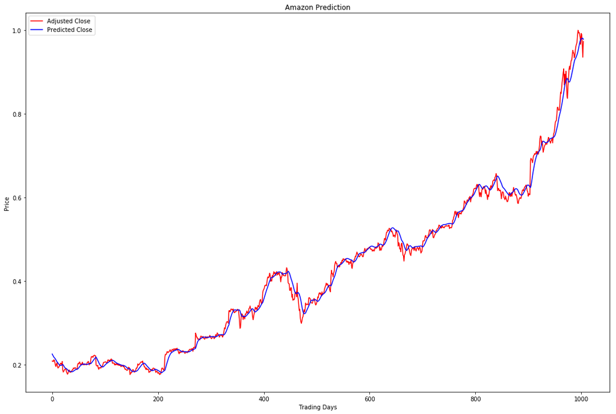

```python
plot_lstm_stock_prediction(y_test,opt_predictions)
```

### Step : 6

**Error/accuracy score of Optimized LSTM model**

```python
model_lstm_score(optimized_lstm_model,X_train, y_train, X_test, y_test)
```

```
Train Score: 0.00000976 MSE (0.00312377 RMSE)
Test Score: 0.00020909 MSE (0.01445986 RMSE)
```

```
(9.7579438092613251e-06, 0.00020908747865721139)
```

## Section - 3 : Data Split, Design GRU Model, Training, Prediction & Accuracy

### Step : 1

**Define the split function for GRU model**

```python
##Define the splity funtion for GRU..
def split_train_test_gru(stock, seq_len, split):
    amount_of_features = len(stock.columns)
    data = stock.values
    sequence_length = seq_len + 1 # index starting from 0
    result = []

#     scaler = RobustScaler()
#     data = scaler.fit_transform(data)

    for index in range(len(data) - sequence_length):
        result.append(data[index: index + sequence_length])

    result = np.array(result)

    row = round(split * result.shape[0])
    train = result[:int(row), :]
    X_train = train[:, :, :-1]
    y_train = train[:, :, -1][:, -1]

    X_test = result[int(row):, :, :-1]
    y_test = result[int(row):, :, -1][:, -1]

    return [X_train, y_train, X_test, y_test]
```

```python
gru_df = df
no_of_features = len(gru_df.columns)
seq_len= 21
split = 0.8
layers = [seq_len, 10]
epochs = 1
```

```python
X_train, y_train, X_test, y_test = split_train_test_gru(gru_df, seq_len, split)
X_train.shape, y_train.shape, X_test.shape, y_test.shape
```

```
((4021, 22, 8), (4021,), (1005, 22, 8), (1005,))
```

### Step : 2

**Define the basic GRU model**

```python
## Build the basic model..
def build_basic_gru_model(layers):
        model = Sequential()

        model.add(GRU(2048, input_shape=(layers[0]+1, layers[1]-1), return_sequences=True))
        model.add(GRU(1024, return_sequences=True))
        model.add(GRU(512, return_sequences=False))

        model.add(Dense(1, activation='linear'))

        model.compile(loss='mse',optimizer='adam', metrics=['accuracy'])
        return model
```

### Step : 3

**Compile the basic GRU model**

```python
gru_basic_model = build_basic_gru_model([seq_len, no_of_features])
```

### Step : 4

**Train basic GRU model**

```python
gru_basic_model.fit(X_train,
                    y_train,
                    epochs=epochs,
                    validation_split=0.2)
```

```
Train on 3216 samples, validate on 805 samples
```

```
<keras.callbacks.History at 0x1a34febc10>
```

### Step : 5

**Prediction using Basic GRU model**

```python
predictions = gru_basic_model.predict(X_test)
```

### Step : 6

**Plot the predictions using Basic GRU model**

```python
plt.rcParams['figure.figsize'] = (18, 12)
## Define a visualize function to plot the gru prediction..
def plot_gru_stock_prediction(actual, prediction, title='Amazon GRU Prediction', y_label='Price', x_label='Trading Days'):

    fig = plt.figure()
    ax = fig.add_subplot(111)

    # Add labels
    plt.ylabel(y_label)
    plt.xlabel(x_label)

    # Plot actual and predicted close values

    plt.plot(actual, 'red', label='Adjusted Close')
    plt.plot(prediction, 'blue', label='Predicted Close')

    # Set title
    ax.set_title(title)
    ax.legend(loc='upper left')

    plt.show()
```

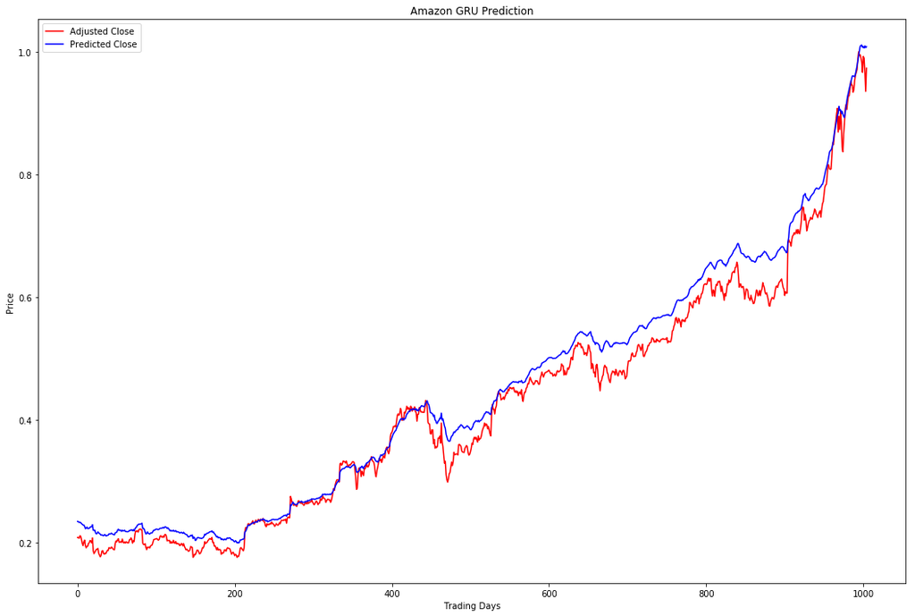

```python
plot_gru_stock_prediction(y_test,predictions)
```

### Step : 7

**Error/accuracy score of Basic GRU model**

```python
## Define a function to eval the errors.
def model_gru_score(model, X_train, y_train, X_test, y_test):
    trainScore = model.evaluate(X_train, y_train, verbose=0)
    print('Train Score: %.8f MSE (%.8f RMSE)' % (trainScore[0], math.sqrt(trainScore[0])))

    testScore = model.evaluate(X_test, y_test, verbose=0)
    print('Test Score: %.8f MSE (%.8f RMSE)' % (testScore[0], math.sqrt(testScore[0])))
    return trainScore[0], testScore[0]
```

```python
model_gru_score(gru_basic_model, X_train, y_train, X_test, y_test)
```

```
Train Score: 0.00002767 MSE (0.00525995 RMSE)
Test Score: 0.00147107 MSE (0.03835451 RMSE)
```

```
(2.7667022326605806e-05, 0.0014710684635894215)
```

### Optimised GRU Model

**Step : 1 - Build the enhanced Model**

```python
def build_optimized_gru_model(layers, d):
        model = Sequential()

        model.add(GRU(2048, input_shape=(layers[0]+1, layers[1]-1), return_sequences=True))
        model.add(Dropout(d))
        model.add(GRU(1024, return_sequences=True))
        model.add(Dropout(d))
        model.add(GRU(512, return_sequences=False))
        model.add(Dropout(d))
        model.add(Dense(1, activation='linear'))

        model.compile(loss='mse',optimizer='adam',metrics=['accuracy'])
        return model
```

### Step : 2

**Compile the enhanced GRU model**

```python
gru_df = df
no_of_features = len(gru_df.columns)
seq_len= 21
split = 0.8
layers = [seq_len, 10]
epochs = 1
batch_size = 100
gru_opt_model = build_optimized_gru_model([seq_len, no_of_features],0.2)
```

### Step : 3

**Train the enhanced GRU model**

```python
gru_opt_model.fit(
                X_train,
                y_train,
                batch_size=batch_size,
                epochs=epochs,
                validation_split=0.2)
```

```
Train on 3216 samples, validate on 805 samples
```

```
<keras.callbacks.History at 0x1a99d5ee50>
```

### Step : 4

**Prediction using Optimized GRU model**

```python
opt_predictions = gru_opt_model.predict(X_test)
```

### Step : 5

**Plot the predictions using Optimized GRU model**

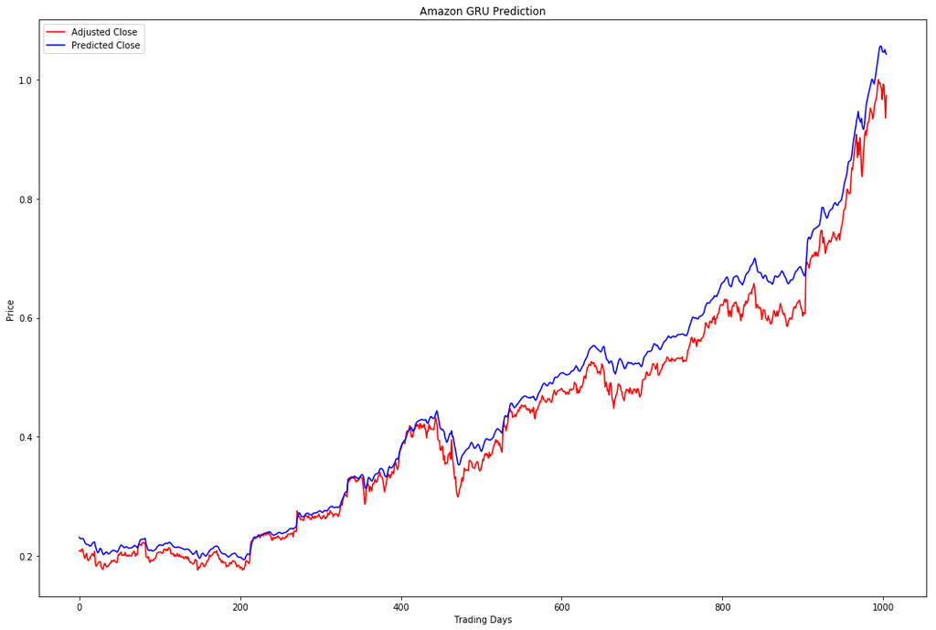

```python
plot_gru_stock_prediction(y_test,opt_predictions)
```

### Step : 6

**Error/accuracy score of Optimized GRU model**

```python
model_gru_score(gru_opt_model, X_train, y_train, X_test, y_test)
```

```
Train Score: 0.00001411 MSE (0.00375587 RMSE)
Test Score: 0.00107527 MSE (0.03279123 RMSE)
```

```
(1.4106579102015763e-05, 0.0010752650523391455)
```